# Zoid - troubleshooting

run date: September 27, 2023

M Fisher

written 2023-09-26

## Goal:

Use zoid to understand how diet varies with instar size (measured as carapace width, mm). Diet information generated with DNA metabarcoding, values in the data matrix represent sequence abundance.

Variation in carapace width looks like:

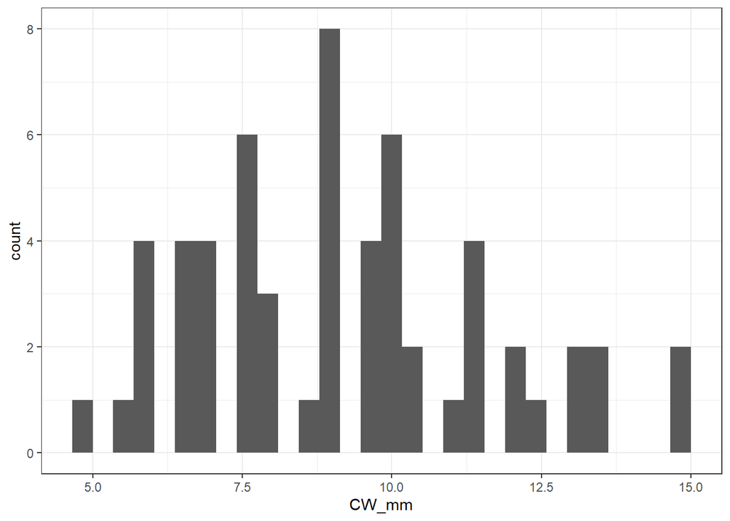

```r
ggplot(cw.df, aes(x=CW_mm)) +
  geom_histogram() + theme_bw()
```

## All taxa, species or lowest tax level

```r
zoidIN.reads <- readRDS(here(resultsdir,'zoidIN_nReads_allTaxa_by_CW.rds'))
dim(zoidIN.reads)
```

```
## [1] 58 61
```

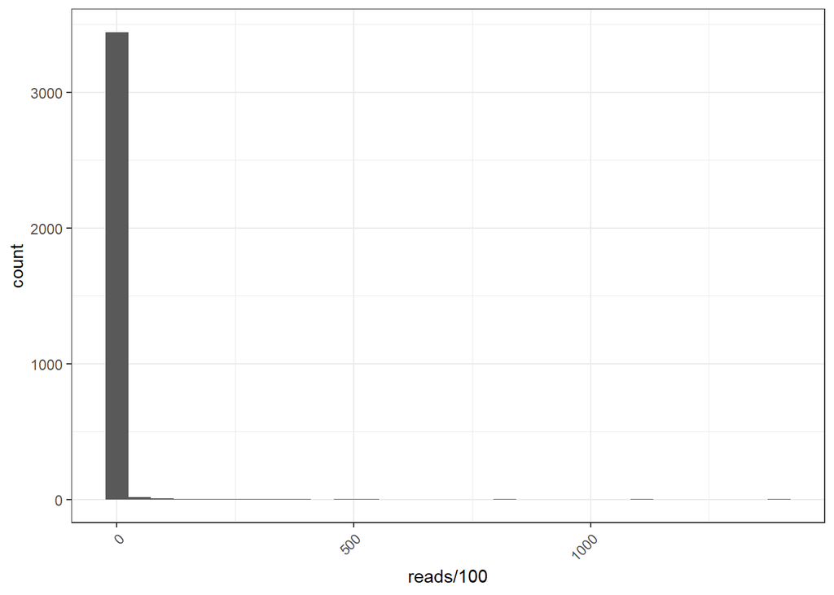

create the design matrix (site / site type information per observation, aka per crab) and the data matrix (read counts only)

```r
design_matrix = zoidIN.reads[,which(names(zoidIN.reads)=="CW_mm"), drop=FALSE]
data_matrix = zoidIN.reads[,which(names(zoidIN.reads)!="CW_mm")]
design_matrix$y = 1 # dummy variable
```

attempt to zoid!

```r
fit_1_prey <- fit_zoid(formula = y ~ CW_mm,
                      design_matrix = design_matrix,
                      data_matrix = as.matrix(data_matrix),
                       overdispersion = TRUE,
                       chains=1,   # for testing; change to 4
                       iter=20)   # for testing; change to 5000
```

Chain 1: Rejecting initial value: Chain 1: Log probability evaluates to log(0), i.e. negative infinity. Chain 1: Stan can’t start sampling from this initial value. Chain 1: Chain 1: Initialization between (-2, 2) failed after 100 attempts. Chain 1: Try specifying initial values, reducing ranges of constrained values, or reparameterizing the model. [1] “Error : Initialization failed.” [1] “error occurred during calling the sampler; sampling not done”

## All taxa, family

```r
zoidIN.FAMreads <- readRDS(here(resultsdir,'zoidIN_nReads_allTaxaFamilies_by_CW.rds'))
dim(zoidIN.FAMreads)
```

```
## [1] 58 57
```

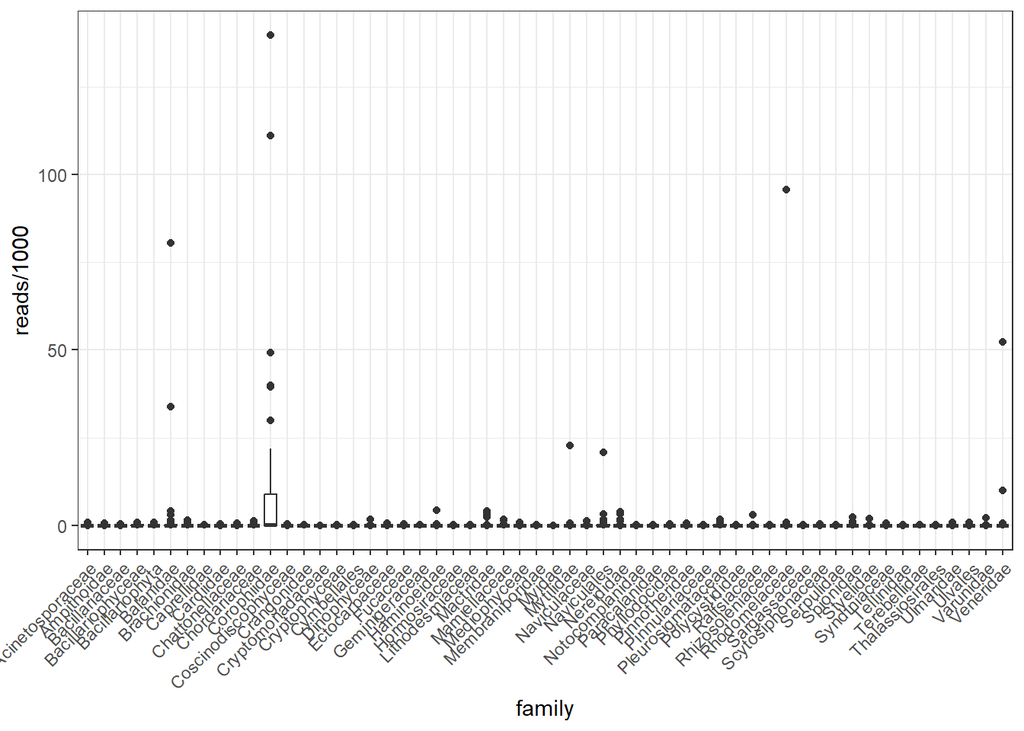

create the design matrix (site / site type information per observation, aka per crab) and the data matrix (read counts only)

```r
design_matrix = zoidIN.FAMreads[,which(names(zoidIN.FAMreads)=="CW_mm"), drop=FALSE]
data_matrix = zoidIN.FAMreads[,which(names(zoidIN.FAMreads)!="CW_mm")]
design_matrix$y = 1 # dummy variable
```

attempt to zoid!

```r
fit_2_prey <- fit_zoid(formula = y ~ CW_mm,
                      design_matrix = design_matrix,
                      data_matrix = as.matrix(data_matrix),
                       overdispersion = TRUE,
                       chains=1,   # for testing; change to 4
                       iter=500)   # for testing; change to 5000
```

Chain 1: Rejecting initial value: Chain 1: Log probability evaluates to log(0), i.e. negative infinity. Chain 1: Stan can’t start sampling from this initial value. Chain 1: Chain 1: Initialization between (-2, 2) failed after 100 attempts. Chain 1: Try specifying initial values, reducing ranges of constrained values, or reparameterizing the model. [1] “Error : Initialization failed.” [1] “error occurred during calling the sampler; sampling not done”

## All taxa, class

```r
zoidIN.CLASSreads <- readRDS(here(resultsdir,'zoidIN_nReads_allTaxaCLASS_by_CW.rds'))
dim(zoidIN.CLASSreads)
```

```
## [1] 58 26
```

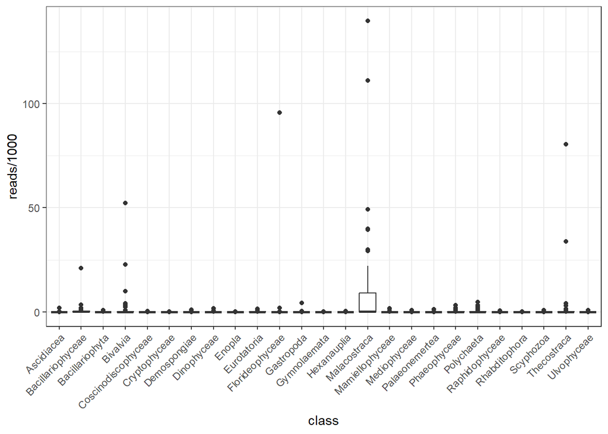

create the design matrix (site / site type information per observation, aka per crab) and the data matrix (read counts only)

```r
design_matrix = zoidIN.CLASSreads[,which(names(zoidIN.CLASSreads)=="CW_mm"), drop=FALSE]
data_matrix = zoidIN.CLASSreads[,which(names(zoidIN.CLASSreads)!="CW_mm")]
design_matrix$y = 1 # dummy variable
```

attempt to zoid!

```r
fit_3_prey <- fit_zoid(formula = y ~ CW_mm,
                      design_matrix = design_matrix,
                      data_matrix = as.matrix(data_matrix),
                       overdispersion = TRUE,
                       chains=1,   # for testing; change to 4
                       iter=500)   # for testing; change to 5000
```